# Natural gas price forecast

```python
import pandas as pd
import matplotlib.pyplot as plt

from scipy.stats import probplot
from utils import PriceEstimator

plt.rcParams.update({
    'text.usetex': True,
    'font.family': 'serif',
    'font.serif': ['Times New Roman'],
    'figure.titlesize': 16,
    'axes.labelsize': 12,
    'axes.titlesize': 14,
    'xtick.labelsize': 10,
    'ytick.labelsize': 10,
    'axes.grid': True,
    'axes.axisbelow': True,
    'grid.alpha': 0.5,
    'axes.spines.right': False,
    'axes.spines.top': False,
    'figure.figsize': (10, 6),
    'figure.dpi': 100,
})
```

Load the monthly natural gas price data.

```python
historical_data = pd.read_csv('Nat_Gas.csv')
historical_data.set_index('Dates', inplace=True)
historical_data.index = pd.to_datetime(historical_data.index,)

historical_data.head()
```

| Dates | Prices |
| --- | --- |
| 2020-10-31 | 10.1 |
| 2020-11-30 | 10.3 |
| 2020-12-31 | 11.0 |
| 2021-01-31 | 10.9 |
| 2021-02-28 | 10.9 |

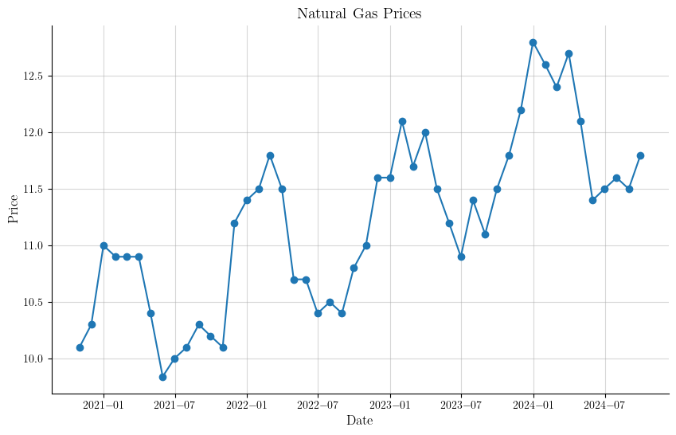

```python
plt.plot(historical_data.index, historical_data['Prices'], marker='o', linestyle='-',)
plt.title('Natural Gas Prices')
plt.xlabel('Date')
plt.ylabel('Price')
plt.show()
```

Analyze the data to estimate the purchase price of gas at any date in the past and extrapolate it for one year into the future.

The price estimate for any date in the past between two points in the dataset will be linearly interpolated between the two points. The forecast for the following year will be based on the trend and seasonality of the historical data.

The trend is estimated by considering the 12-month moving average of the data, which is shown in the plot below.

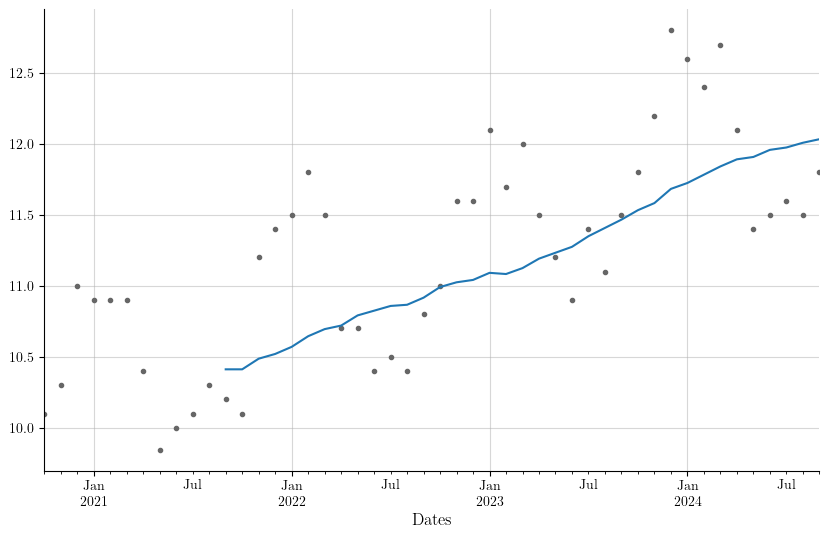

```python
moving_avg = historical_data['Prices'].rolling(window=12).mean()

ax = historical_data['Prices'].plot(style='.', color='#666')
moving_avg.plot(ax=ax, color='tab:blue')
plt.show()
```

The trend is approximately linear, so a linear regression model combined with Fourier terms is used to estimate the trend and seasonality.

The optimal order of the Fourier series is determined by considering the RMSE of the model and the p-value of the Shapiro-Wilk test for the residuals.

```python
def find_best_model(data, max_order):
    validation_results = pd.DataFrame(columns=["p", "rmse"], index=range(1, max_order+1))
    for order in range(1, max_order+1):
        candidate_model = PriceEstimator(data, fourier_order=order)
        p, rmse = candidate_model.validate_model()
        validation_results.loc[order] = p, rmse

    return validation_results
```

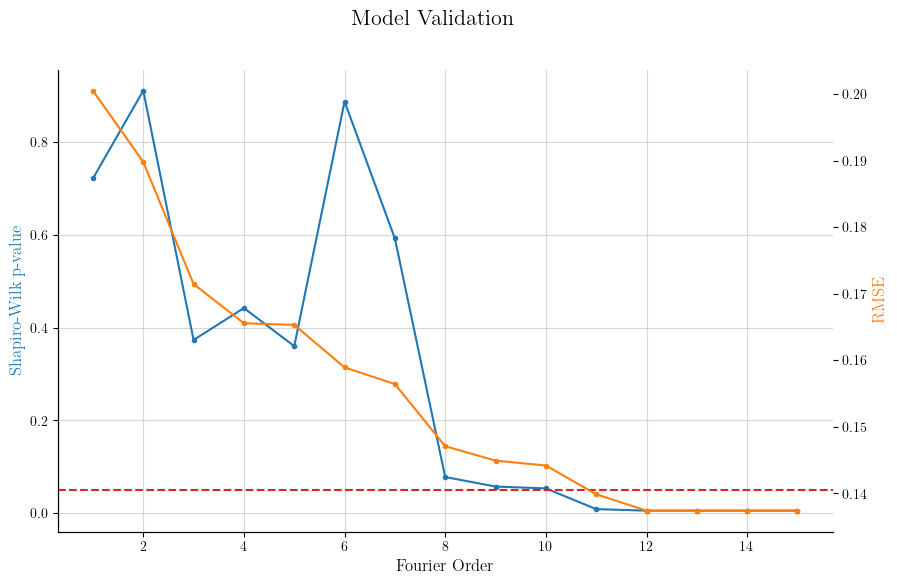

```python
validation_results = find_best_model(historical_data, 15)
fig, ax = plt.subplots()
ax2 = ax.twinx()
ax.plot(validation_results.index, validation_results["p"], color='tab:blue', marker='.')
ax.axhline(0.05, color='tab:red', linestyle='--')
ax2.plot(validation_results.index, validation_results["rmse"], color='tab:orange', marker='.')
ax.set_xlabel("Fourier Order")
ax.set_ylabel("Shapiro-Wilk p-value", color='tab:blue')
ax2.set_ylabel("RMSE", color='tab:orange')
ax2.grid(False)
fig.suptitle("Model Validation")
plt.show()
```

The RMSE decreases as the order of the Fourier series increases, indicating that the model is overfitting the data. The p-value of the Shapiro-Wilk test also decreases, although not monotonically. This means that as the order of the Fourier series increases, the residuals are further from a normal distribution.

A trade-off between the two metrics is achieved by setting the order of the Fourier series to 6.

```python
best_model = PriceEstimator(historical_data, fourier_order=6)
residuals = best_model.get_residuals()
```

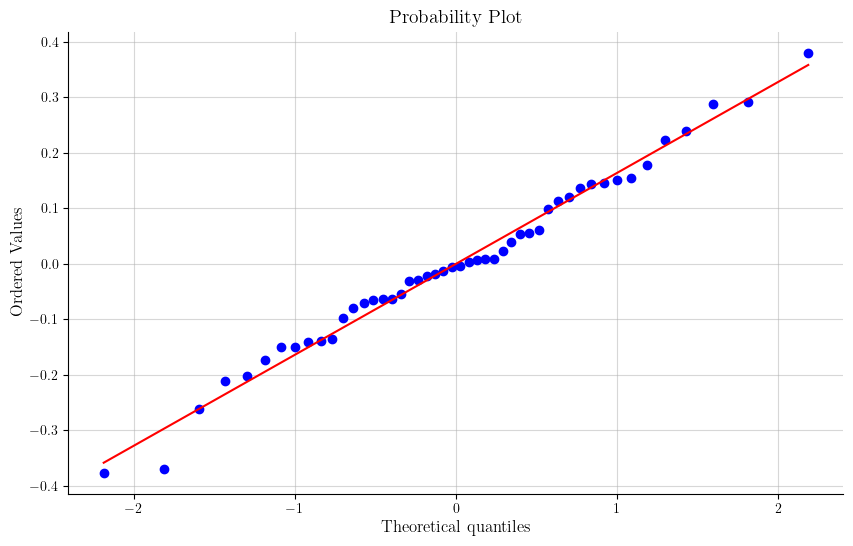

```python
fig, ax = plt.subplots()
probplot(residuals, dist='norm', plot=ax)
plt.show()
```

The following figure shows the fitted model against the historical data, as well as the forecast for the next year. Some overfitting can still be noticed, but the dimension of the dataset is too small to draw significant statistical conclusions.

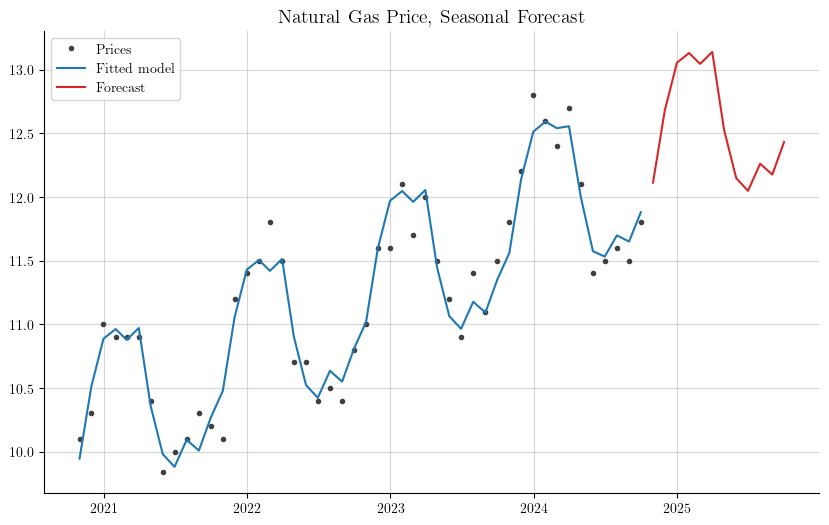

```python
y = historical_data['Prices']
y_pred = best_model.get_fitted_values()
y_forecast = best_model.get_forecast()

_, ax = plt.subplots()
ax.plot(y, color='0.25', marker='.', label="Prices", linestyle='None')
ax.plot(y_pred, label="Fitted model")
ax.plot(y_forecast, label="Forecast", color='C3')
ax.legend()
ax.set_title("Natural Gas Price, Seasonal Forecast")
plt.show()
```

The historical data and the forecast are collected in a dataframe and interpolated to produce data with a daily frequency.

```python
estimates = best_model.estimates
```

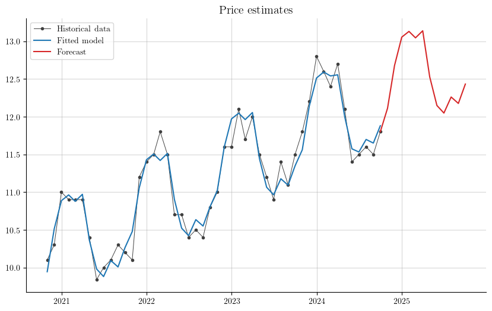

```python
_, ax = plt.subplots()
ax.plot(estimates.loc[historical_data.index, 'Prices'], marker='.', color='0.25', label='Historical data', linewidth=0.7)
ax.plot(y_pred, label='Fitted model')
ax.plot(estimates.loc[historical_data.index[-1]:,'Estimate'], label='Forecast', color='C3')
ax.legend()
ax.set_title('Price estimates')
plt.show()
```

The price estimate for any date in the past is simply the value of the interpolated series at that date. No assumptions are made about the confidence interval of this estimate.

```python
date = '2024-04-13'
price_est = best_model.get_price_estimate(date)
print(f'Estimated price: {price_est:.2f}')
```

```
Estimated price: 12.44
```

The price estimate for any date in the future is obtained by the fitted model. It is simplicistically assumed that the variance of the residuals is constant over time, therefore the 3-sigma confidence interval is determined by considering the residuals of the historical data.

```python
date = '2025-01-06'
price_est = best_model.get_price_estimate(date)
std = residuals.std()
print(f'Estimated price: {price_est:.2f} +/- {3*std:.2f} (3 std dev)')
```

```
Estimated price: 13.07 +/- 0.48 (3 std dev)
```